# Reproducible Research: Peer Assessment 1

## Imputing missing values

Note that there are a number of days/intervals where there are missing values (coded as NA). The presence of missing days may introduce bias into some calculations or summaries of the data.

1. Calculate and report the total number of missing values in the dataset (i.e. the total number of rows with NAs)

```r
numna <- sum(is.na(activity$steps))
numna
```

```
## [1] 2304
```

There are 2304 missing values in the dataset.

2. Devise a strategy for filling in all of the missing values in the dataset. The strategy does not need to be sophisticated. For example, you could use the mean/median for that day, or the mean for that 5-minute interval, etc.

Assuming number of steps taken in each 5-minute interval are similar across all the days, the missing values are replaced by the average number of steps taken in the 5-minute interval across all days. A function impute() is written to replace all the missing value with the average number of steps of each interval.

```r
impute <- function(data = activity) {
    intave <- tapply(activity$steps, activity$interval, mean, na.rm = TRUE)
    t1 <- data.frame(interval = unique(activity$interval), steps = intave)
    nd <- data.frame(steps = data$steps, date = data$date, interval = data$interval)
    for (i in 1:nrow(data))
        if(is.na(data$steps[i]) == TRUE) {
            nd$steps[i] <- intave[match(data$interval[i], t1$interval)]
        } else {
            nd$steps[i] <- data$steps[i]
        }
    nd
}
```

3. Create a new dataset that is equal to the original dataset but with the missing data filled in.

```r
nd <- impute(activity)
head(nd)
```

```
##       steps       date interval
## 1 1.7169811 2012-10-01        0
## 2 0.3396226 2012-10-01        5
## 3 0.1320755 2012-10-01       10
## 4 0.1509434 2012-10-01       15
## 5 0.0754717 2012-10-01       20
## 6 2.0943396 2012-10-01       25
```

```r
newsumbydate <- tapply(nd$steps, nd$date, sum)
head(newsumbydate)
```

```
## 2012-10-01 2012-10-02 2012-10-03 2012-10-04 2012-10-05 2012-10-06
##   10766.19     126.00   11352.00   12116.00   13294.00   15420.00
```

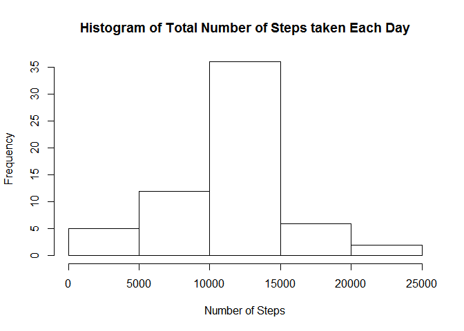

```r
hist(newsumbydate, xlab = "Number of Steps", ylab = "Frequency", main = "")
title(main = "Histogram of Total Number of Steps taken Each Day")
```

```r
newmean <- mean(newsumbydate, na.rm = TRUE)
newmedian <- median(newsumbydate, na.rm = TRUE)
```

## Are there differences in activity patterns between weekdays and weekends?

For this part the weekdays() function may be of some help here. Use the dataset with the filled-in missing values for this part.

1. Create a new factor variable in the dataset with two levels - “weekday” and “weekend” indicating whether a given date is a weekday or weekend day.

```r
weekday <- c("Monday", "Tuesday", "Wednesday", "Thursday", "Friday")
weekend <- c("Saturday", "Sunday")
nd$day <- weekdays(nd$date)
for (i in 1:nrow(nd)) {
    if(nd$day[i] %in% weekday)
        nd$weekday[i] <- "weekday"
    else if (nd$day[i] %in% weekend)
        nd$weekday[i] <- "weekend"
}
head(split(nd, nd$interval), 1)
```

```
## $`0`
##           steps       date interval       day weekday
## 1      1.716981 2012-10-01        0    Monday weekday
## 289    0.000000 2012-10-02        0   Tuesday weekday
## 577    0.000000 2012-10-03        0 Wednesday weekday
## 865   47.000000 2012-10-04        0  Thursday weekday
## 1153   0.000000 2012-10-05        0    Friday weekday
## 1441   0.000000 2012-10-06        0  Saturday weekend
## 1729   0.000000 2012-10-07        0    Sunday weekend
## 2017   1.716981 2012-10-08        0    Monday weekday
## 2305   0.000000 2012-10-09        0   Tuesday weekday
## 2593  34.000000 2012-10-10        0 Wednesday weekday
## 2881   0.000000 2012-10-11        0  Thursday weekday
## 3169   0.000000 2012-10-12        0    Friday weekday
## 3457   0.000000 2012-10-13        0  Saturday weekend
```

[output cut: 48 more lines]

2. Make a panel plot containing a time series plot (i.e. type = “l”) of the 5-minute interval (x-axis) and the average number of steps taken, averaged across all weekday days or weekend days (y-axis). See the README file in the GitHub repository to see an example of what this plot should look like using simulated data.

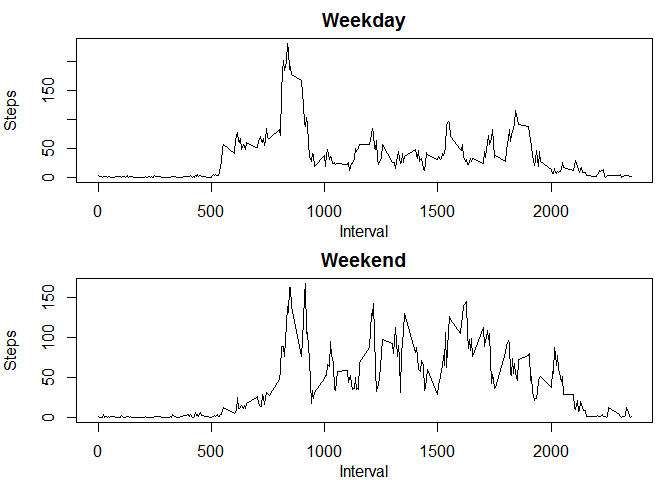

```r
par(mfrow = c(2, 1), mar = c(3, 4, 2, 1))
weekdaynd <- nd[nd$weekday == "weekday", ]
weekendnd <- nd[nd$weekday == "weekend", ]
avewday <- data.frame(interval = unique(nd$interval), steps = tapply(weekdaynd$steps, weekdaynd$interval, mean, na.rm = TRUE))
avewend <- data.frame(interval = unique(nd$interval), steps = tapply(weekendnd$steps, weekendnd$interval, mean, na.rm = TRUE))
plot(avewday, type = "l", main = "Weekday", xlab = "", ylab = "Steps")
mtext("Interval", side = 1, line = 2)
plot(avewend, type = "l", main = "Weekend", xlab = "", ylab = "Steps")
mtext("Interval", side = 1, line = 2)
```